# Biostat 212a Homework 4

Due Mar. 5, 2024 @ 11:59PM

Author

Li Zhang 206305918

Published

March 1, 2024

```r
library(GGally)
library(gtsummary)
library(ranger)
library(tidyverse)
library(tidymodels)
library(ISLR2)
```

## 1 ISL Exercise 8.4.3 (10pts)

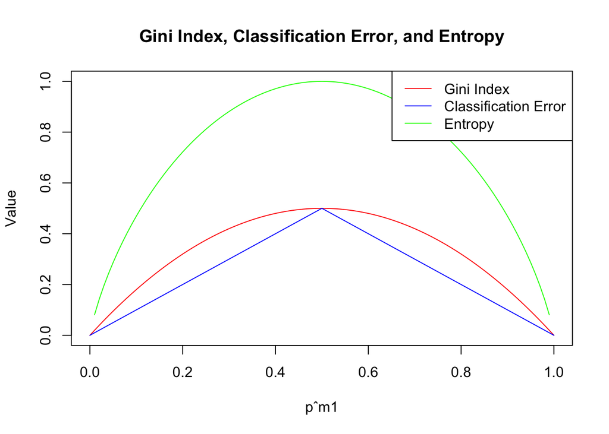

```r
# Generate sequence of pˆm1 values
p_m1 <- seq(0, 1, by = 0.01)

# Calculate corresponding values of Gini index, classification error, and entropy
gini <- 2 * p_m1 * (1 - p_m1)
classification_error <- 1 - pmax(p_m1, 1 - p_m1)
entropy <- -p_m1 * log2(p_m1) - (1 - p_m1) * log2(1 - p_m1)

# Plot
plot(p_m1, gini, type = "l", col = "red", ylim = c(0, 1), xlab = "pˆm1", ylab = "Value", main = "Gini Index, Classification Error, and Entropy")
lines(p_m1, classification_error, type = "l", col = "blue")
lines(p_m1, entropy, type = "l", col = "green")
legend("topright", legend = c("Gini Index", "Classification Error", "Entropy"), col = c("red", "blue", "green"), lty = 1)
```

## 2 ISL Exercise 8.4.4 (10pts)

Here is my tree:

[figure not shown]

Here is my diagram:

[figure not shown]

## 3 ISL Exercise 8.4.5 (10pts)

```r
p = c(0.1, 0.15, 0.2, 0.2, 0.55, 0.6, 0.6, 0.65, 0.7, 0.75)
sum(p >= 0.5) > sum(p < 0.5)
```

```
[1] TRUE
```

So, the majority class is `p >= 0.5` and the final classification is **red**.

```r
mean(p)
```

```
[1] 0.45
```

```r
mean(p) > 0.5
```

```
[1] FALSE
```

## 4 ISL Lab 8.3. `Boston` data set (30pts)

Follow the machine learning workflow to train regression tree, random forest, and boosting methods for predicting `medv`. Evaluate out-of-sample performance on a test set.

### 4.1 Boston dataset

```r
Boston %>% tbl_summary()
```

| **Characteristic** | **N = 506**<sup>1</sup> |
| --- | --- |
| crim | 0.3 (0.1, 3.7) |
| zn | 0 (0, 13) |
| indus | 9.7 (5.2, 18.1) |
| chas | 35 (6.9%) |
| nox | 0.54 (0.45, 0.62) |
| rm | 6.21 (5.89, 6.62) |
| age | 78 (45, 94) |
| dis | 3.21 (2.10, 5.19) |
| rad |  |
| 1 | 20 (4.0%) |
| 2 | 24 (4.7%) |
| 3 | 38 (7.5%) |
| 4 | 110 (22%) |
| 5 | 115 (23%) |
| 6 | 26 (5.1%) |
| 7 | 17 (3.4%) |
| 8 | 24 (4.7%) |
| 24 | 132 (26%) |
| tax | 330 (279, 666) |
| ptratio | 19.05 (17.40, 20.20) |
| lstat | 11 (7, 17) |
| medv | 21 (17, 25) |

<sup>1</sup> Median (IQR); n (%)

```r
Boston <- Boston %>% filter(!is.na(medv))
```

### 4.2 Initial split into test and non-test sets

We randomly split the data in half of test data and another half of non-test data.

```r
# For reproducibility
set.seed(203)

data_split <- initial_split(
  Boston,
  prop = 0.5
  )
data_split
```

```
<Training/Testing/Total>
<253/253/506>
```

```r
Boston_other <- training(data_split)
dim(Boston_other)
```

```
[1] 253  13
```

```r
Boston_test <- testing(data_split)
dim(Boston_test)
```

```
[1] 253  13
```

### 4.3 Regression tree

#### 4.3.1 Recipe

```r
tree_recipe <-
  recipe(
    medv ~ .,
    data = Boston_other
  ) %>%
  # # create traditional dummy variables (not necessary for random forest in R)
  # step_dummy(all_nominal()) %>%
  step_naomit(medv) %>%
  # zero-variance filter
  step_zv(all_numeric_predictors()) %>%
  # # center and scale numeric data (not necessary for random forest)
  # step_normalize(all_numeric_predictors()) %>%
  # estimate the means and standard deviations
  prep(training = Boston_other, retain = TRUE)
tree_recipe
```

#### 4.3.2 Model

```r
regtree_mod <- decision_tree(
  cost_complexity = tune(),
  tree_depth = tune(),
  min_n = 5,
  mode = "regression",
  engine = "rpart"
  )
```

#### 4.3.3 Workflow

Here we bundle the recipe and model.

```r
tree_wf <- workflow() %>%
  add_recipe(tree_recipe) %>%
  add_model(regtree_mod)
tree_wf
```

```
══ Workflow ════════════════════════════════════════════════════════════════════
Preprocessor: Recipe
Model: decision_tree()

── Preprocessor ────────────────────────────────────────────────────────────────
2 Recipe Steps

• step_naomit()
• step_zv()

── Model ───────────────────────────────────────────────────────────────────────
Decision Tree Model Specification (regression)

Main Arguments:
  cost_complexity = tune()
  tree_depth = tune()
  min_n = 5

Computational engine: rpart
```

#### 4.3.4 Tuning grid

`ccp_alpha` is the Minimal Cost-Complexity Pruning parameter. Greater values of `ccp_alpha` increase the number of nodes pruned.

```r
tree_grid <- grid_regular(cost_complexity(),
                          tree_depth(),
                          levels = c(100, 5))
```

#### 4.3.5 Cross-validation (CV)

Set cross-validation partitions.

```r
set.seed(203)

folds <- vfold_cv(Boston_other, v = 5)
folds
```

```
#  5-fold cross-validation
# A tibble: 5 × 2
  splits           id
  <list>           <chr>
1 <split [202/51]> Fold1
2 <split [202/51]> Fold2
3 <split [202/51]> Fold3
4 <split [203/50]> Fold4
5 <split [203/50]> Fold5
```

Fit cross-validation.

```r
tree_fit <- tree_wf %>%
  tune_grid(
    resamples = folds,
    grid = tree_grid,
    metrics = metric_set(rmse, rsq)
    )
tree_fit
```

```
# Tuning results
# 5-fold cross-validation
# A tibble: 5 × 4
  splits           id    .metrics             .notes
  <list>           <chr> <list>               <list>
1 <split [202/51]> Fold1 <tibble [1,000 × 6]> <tibble [0 × 3]>
2 <split [202/51]> Fold2 <tibble [1,000 × 6]> <tibble [0 × 3]>
3 <split [202/51]> Fold3 <tibble [1,000 × 6]> <tibble [0 × 3]>
4 <split [203/50]> Fold4 <tibble [1,000 × 6]> <tibble [0 × 3]>
5 <split [203/50]> Fold5 <tibble [1,000 × 6]> <tibble [0 × 3]>
```

Visualize CV results:

```
# A tibble: 1,000 × 8
   cost_complexity tree_depth .metric .estimator  mean     n std_err
             <dbl>      <int> <chr>   <chr>      <dbl> <int>   <dbl>
 1        1   e-10          1 rmse    standard   7.94      5  0.442
 2        1   e-10          1 rsq     standard   0.347     5  0.0740
 3        1.23e-10          1 rmse    standard   7.94      5  0.442
 4        1.23e-10          1 rsq     standard   0.347     5  0.0740
 5        1.52e-10          1 rmse    standard   7.94      5  0.442
 6        1.52e-10          1 rsq     standard   0.347     5  0.0740
 7        1.87e-10          1 rmse    standard   7.94      5  0.442
 8        1.87e-10          1 rsq     standard   0.347     5  0.0740
 9        2.31e-10          1 rmse    standard   7.94      5  0.442
10        2.31e-10          1 rsq     standard   0.347     5  0.0740
   .config
   <chr>
 1 Preprocessor1_Model001
 2 Preprocessor1_Model001
 3 Preprocessor1_Model002
 4 Preprocessor1_Model002
 5 Preprocessor1_Model003
 6 Preprocessor1_Model003
 7 Preprocessor1_Model004
 8 Preprocessor1_Model004
 9 Preprocessor1_Model005
10 Preprocessor1_Model005
# ℹ 990 more rows
```

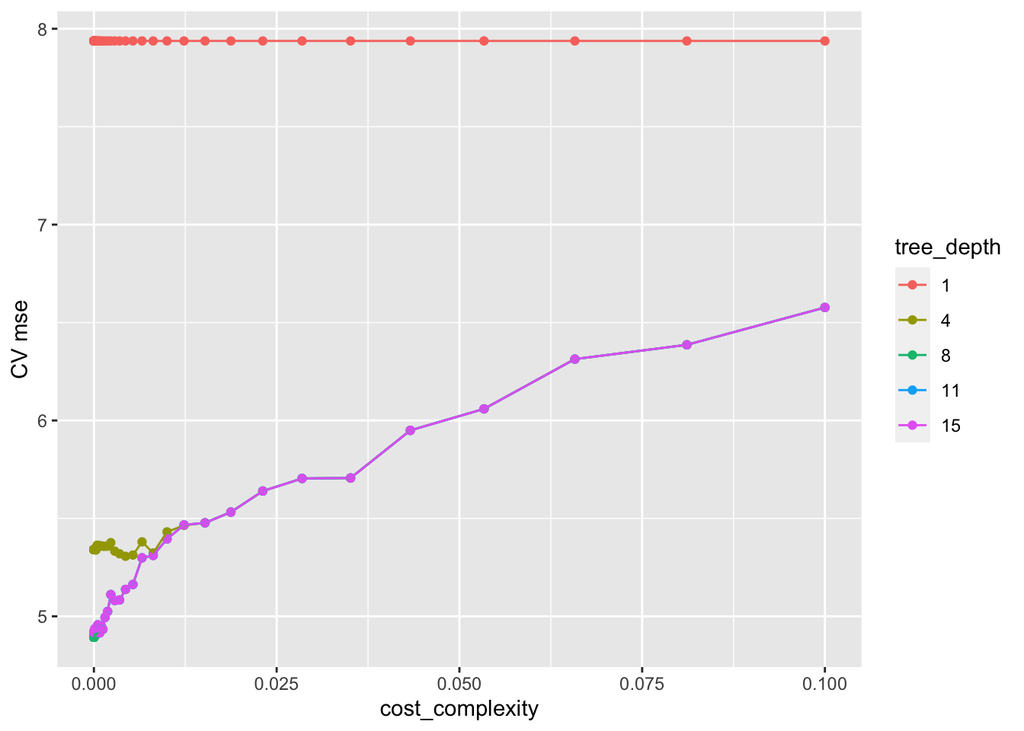

```r
tree_fit %>%
  collect_metrics() %>%
  print(width = Inf) %>%
  filter(.metric == "rmse") %>%
  mutate(tree_depth = as.factor(tree_depth)) %>%
  ggplot(mapping = aes(x = cost_complexity, y = mean, color = tree_depth)) +
  geom_point() +
  geom_line() +
  labs(x = "cost_complexity", y = "CV mse")
```

#### 4.3.6 Finalize our model

Now we are done tuning. Finally, let’s fit this final model to the whole training data and use our test data to estimate the model performance we expect to see with new data.

```r
tree_fit %>%
  show_best("rmse")
```

```
# A tibble: 5 × 8
  cost_complexity tree_depth .metric .estimator  mean     n std_err .config
            <dbl>      <int> <chr>   <chr>      <dbl> <int>   <dbl> <chr>
1        1   e-10          8 rmse    standard    4.89     5   0.717 Preprocesso…
2        1.23e-10          8 rmse    standard    4.89     5   0.717 Preprocesso…
3        1.52e-10          8 rmse    standard    4.89     5   0.717 Preprocesso…
4        1.87e-10          8 rmse    standard    4.89     5   0.717 Preprocesso…
5        2.31e-10          8 rmse    standard    4.89     5   0.717 Preprocesso…
```

Let’s select the best model.

```r
best_tree <- tree_fit %>%
  select_best("rmse")
best_tree
```

```
# A tibble: 1 × 3
  cost_complexity tree_depth .config
            <dbl>      <int> <chr>
1    0.0000000001          8 Preprocessor1_Model201
```

```r
# Final workflow
final_wf <- tree_wf %>%
  finalize_workflow(best_tree)
final_wf
```

```
══ Workflow ════════════════════════════════════════════════════════════════════
Preprocessor: Recipe
Model: decision_tree()

── Preprocessor ────────────────────────────────────────────────────────────────
2 Recipe Steps

• step_naomit()
• step_zv()

── Model ───────────────────────────────────────────────────────────────────────
Decision Tree Model Specification (regression)

Main Arguments:
  cost_complexity = 1e-10
  tree_depth = 8
  min_n = 5

Computational engine: rpart
```

```r
# Fit the whole training set, then predict the test cases
final_fit <-
  final_wf %>%
  last_fit(data_split)
final_fit
```

```
# Resampling results
# Manual resampling
# A tibble: 1 × 6
  splits            id               .metrics .notes   .predictions .workflow
  <list>            <chr>            <list>   <list>   <list>       <list>
1 <split [253/253]> train/test split <tibble> <tibble> <tibble>     <workflow>
```

```r
# Test metrics
final_fit %>%
  collect_metrics()
```

```
# A tibble: 2 × 4
  .metric .estimator .estimate .config
  <chr>   <chr>          <dbl> <chr>
1 rmse    standard       5.07  Preprocessor1_Model1
2 rsq     standard       0.720 Preprocessor1_Model1
```

#### 4.3.7 Visualize the final model

```r
library(rpart.plot)
final_tree <- extract_workflow(final_fit)
final_tree
```

```
══ Workflow [trained] ══════════════════════════════════════════════════════════
Preprocessor: Recipe
Model: decision_tree()

── Preprocessor ────────────────────────────────────────────────────────────────
2 Recipe Steps

• step_naomit()
• step_zv()

── Model ───────────────────────────────────────────────────────────────────────
n= 253

node), split, n, deviance, yval
      * denotes terminal node

  1) root 253 2.337441e+04 22.451380
    2) rm< 6.754 208 8.878604e+03 19.383650
      4) lstat>=14.75 83 1.457504e+03 14.308430
        8) crim>=5.22624 42 4.284764e+02 11.764290
         16) lstat>=20.2 22 2.211150e+02 10.150000
           32) nox>=0.6425 19 8.364000e+01  9.200000
             64) lstat>=24.235 9 1.810889e+01  7.611111
              128) dis< 1.5094 2 8.450000e-01  5.650000 *
              129) dis>=1.5094 7 7.374286e+00  8.171429
                258) crim>=16.97245 3 8.000000e-02  7.200000 *
                259) crim< 16.97245 4 2.340000e+00  8.900000 *
             65) lstat< 24.235 10 2.236100e+01 10.630000
              130) nox< 0.6965 5 9.652000e+00  9.760000
                260) age>=99.55 2 4.500000e+00  8.700000 *
                261) age< 99.55 3 1.406667e+00 10.466670 *
              131) nox>=0.6965 5 5.140000e+00 11.500000
                262) crim>=11.98135 2 4.500000e-02 10.650000 *
                263) crim< 11.98135 3 2.686667e+00 12.066670 *
           33) nox< 0.6425 3 1.172667e+01 16.166670 *
         17) lstat< 20.2 20 8.696800e+01 13.540000
           34) age< 99.45 17 6.234471e+01 13.082350
             68) rm< 5.817 2 5.120000e+00 10.100000 *
             69) rm>=5.817 15 3.706400e+01 13.480000
              138) crim>=13.6366 2 2.205000e+00 10.650000 *
```

[output cut: 9 more lines]

```
              146) ptratio>=20.6 4 4.200000e-01 13.200000 *
              147) ptratio< 20.6 8 4.035500e+01 16.325000
                294) nox>=0.6485 4 1.338750e+01 15.125000 *
                295) nox< 0.6485 4 1.544750e+01 17.525000 *
           37) lstat< 18.845 23 1.051574e+02 17.347830
             74) crim>=0.614845 9 3.426222e+01 15.755560
              148) crim< 3.9419 6 1.030000e+01 14.800000
                296) lstat>=15.58 4 4.730000e+00 14.150000 *
                297) lstat< 15.58 2 5.000000e-01 16.100000 *
              149) crim>=3.9419 3 7.526667e+00 17.666670 *
             75) crim< 0.614845 14 3.340857e+01 18.371430
              150) nox>=0.5455 8 8.738750e+00 17.362500

...
and 70 more lines.
```

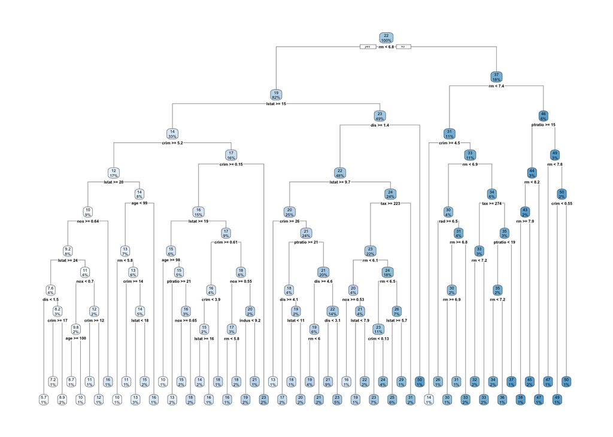

```r
final_tree %>%
  extract_fit_engine() %>%
  rpart.plot(roundint = FALSE)
```

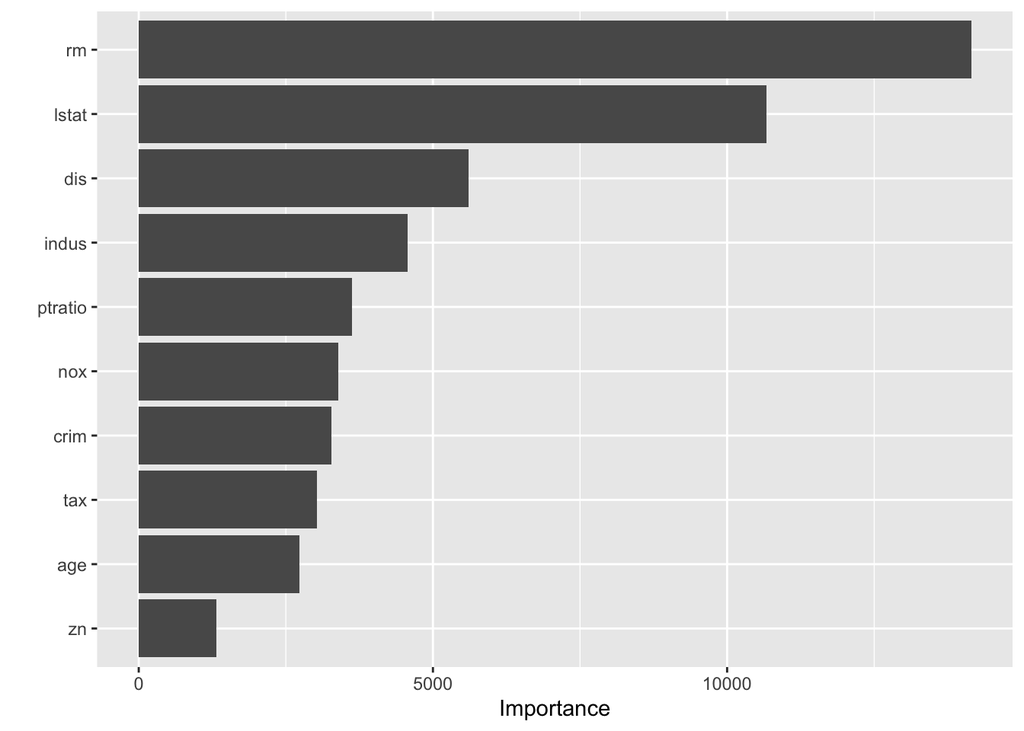

```r
library(vip)

final_tree %>%
  extract_fit_parsnip() %>%
  vip()
```

### 4.4 Random forest

#### 4.4.1 Recipe

```r
rf_recipe <-
  recipe(
    medv ~ .,
    data = Boston_other
  ) %>%
  # # create traditional dummy variables (not necessary for random forest in R)
  # step_dummy(all_nominal()) %>%
  step_naomit(medv) %>%
  # zero-variance filter
  step_zv(all_numeric_predictors()) %>%
  # # center and scale numeric data (not necessary for random forest)
  # step_normalize(all_numeric_predictors()) %>%
  # estimate the means and standard deviations
  prep(training = Boston_other, retain = TRUE)
rf_recipe
```

#### 4.4.2 Model

```r
rf_mod <-
  rand_forest(
    mode = "regression",
    # Number of predictors randomly sampled in each split
    mtry = tune(),
    # Number of trees in ensemble
    trees = tune()
  ) %>%
  set_engine("ranger")
rf_mod
```

```
Random Forest Model Specification (regression)

Main Arguments:
  mtry = tune()
  trees = tune()

Computational engine: ranger
```

#### 4.4.3 Workflow

```r
rf_wf <- workflow() %>%
  add_recipe(rf_recipe) %>%
  add_model(rf_mod)
rf_wf
```

```
══ Workflow ════════════════════════════════════════════════════════════════════
Preprocessor: Recipe
Model: rand_forest()

── Preprocessor ────────────────────────────────────────────────────────────────
2 Recipe Steps

• step_naomit()
• step_zv()

── Model ───────────────────────────────────────────────────────────────────────
Random Forest Model Specification (regression)

Main Arguments:
  mtry = tune()
  trees = tune()

Computational engine: ranger
```

#### 4.4.4 Tuning grid

In general, it’s not necessary to tune a random forest. Using the default of `n_estimators=100` and `max_features=1.0` (bagging) or `max_features='sqrt'` works well.

Here we tune the number of trees `n_estimators` and the number of features to use in each split `max_features`.

Here we tune the number of trees `trees` and the number of features to use in each split `mtry`.

```r
param_grid <- grid_regular(
  trees(range = c(100L, 300L)),
  mtry(range = c(1L, 5L)),
  levels = c(3, 5)
  )
param_grid
```

```
# A tibble: 15 × 2
   trees  mtry
   <int> <int>
 1   100     1
 2   200     1
 3   300     1
 4   100     2
 5   200     2
 6   300     2
 7   100     3
 8   200     3
 9   300     3
10   100     4
11   200     4
12   300     4
13   100     5
14   200     5
15   300     5
```

#### 4.4.5 Cross-validation (CV)

Set cross-validation partitions.

```r
set.seed(203)

folds <- vfold_cv(Boston_other, v = 5)
folds
```

```
#  5-fold cross-validation
# A tibble: 5 × 2
  splits           id
  <list>           <chr>
1 <split [202/51]> Fold1
2 <split [202/51]> Fold2
3 <split [202/51]> Fold3
4 <split [203/50]> Fold4
5 <split [203/50]> Fold5
```

Fit cross-validation.

```r
rf_fit <- rf_wf %>%
  tune_grid(
    resamples = folds,
    grid = param_grid,
    metrics = metric_set(rmse, rsq)
    )
rf_fit
```

```
# Tuning results
# 5-fold cross-validation
# A tibble: 5 × 4
  splits           id    .metrics          .notes
  <list>           <chr> <list>            <list>
1 <split [202/51]> Fold1 <tibble [30 × 6]> <tibble [0 × 3]>
2 <split [202/51]> Fold2 <tibble [30 × 6]> <tibble [0 × 3]>
3 <split [202/51]> Fold3 <tibble [30 × 6]> <tibble [0 × 3]>
4 <split [203/50]> Fold4 <tibble [30 × 6]> <tibble [0 × 3]>
5 <split [203/50]> Fold5 <tibble [30 × 6]> <tibble [0 × 3]>
```

Visualize CV results:

```
# A tibble: 30 × 8
    mtry trees .metric .estimator  mean     n std_err .config
   <int> <int> <chr>   <chr>      <dbl> <int>   <dbl> <chr>
 1     1   100 rmse    standard   5.16      5  0.424  Preprocessor1_Model01
 2     1   100 rsq     standard   0.739     5  0.0827 Preprocessor1_Model01
 3     1   200 rmse    standard   5.07      5  0.434  Preprocessor1_Model02
 4     1   200 rsq     standard   0.745     5  0.0842 Preprocessor1_Model02
 5     1   300 rmse    standard   5.14      5  0.470  Preprocessor1_Model03
 6     1   300 rsq     standard   0.739     5  0.0915 Preprocessor1_Model03
 7     2   100 rmse    standard   4.27      5  0.552  Preprocessor1_Model04
 8     2   100 rsq     standard   0.797     5  0.0811 Preprocessor1_Model04
 9     2   200 rmse    standard   4.41      5  0.559  Preprocessor1_Model05
10     2   200 rsq     standard   0.784     5  0.0858 Preprocessor1_Model05
# ℹ 20 more rows
```

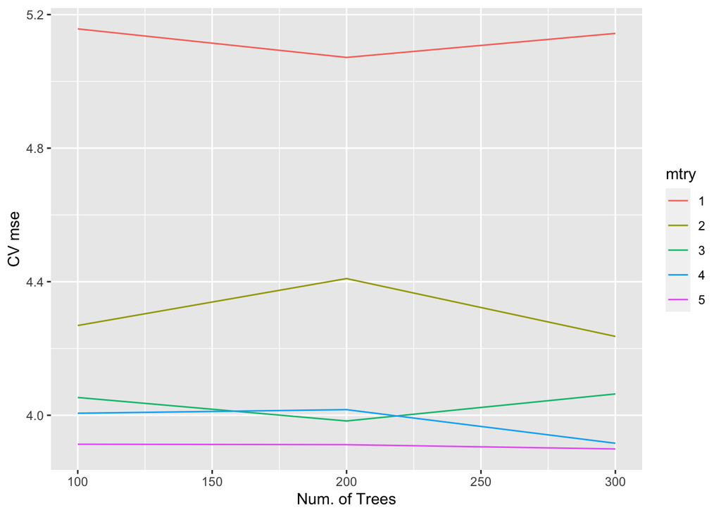

```r
rf_fit %>%
  collect_metrics() %>%
  print(width = Inf) %>%
  filter(.metric == "rmse") %>%
  mutate(mtry = as.factor(mtry)) %>%
  ggplot(mapping = aes(x = trees, y = mean, color = mtry)) +
  # geom_point() +
  geom_line() +
  labs(x = "Num. of Trees", y = "CV mse")
```

Show the top 5 models.

```r
rf_fit %>%
  show_best("rmse")
```

```
# A tibble: 5 × 8
   mtry trees .metric .estimator  mean     n std_err .config
  <int> <int> <chr>   <chr>      <dbl> <int>   <dbl> <chr>
1     5   300 rmse    standard    3.90     5   0.598 Preprocessor1_Model15
2     5   200 rmse    standard    3.91     5   0.598 Preprocessor1_Model14
3     5   100 rmse    standard    3.91     5   0.691 Preprocessor1_Model13
4     4   300 rmse    standard    3.92     5   0.629 Preprocessor1_Model12
5     3   200 rmse    standard    3.98     5   0.596 Preprocessor1_Model08
```

Let’s select the best model.

```r
best_rf <- rf_fit %>%
  select_best("rmse")
best_rf
```

```
# A tibble: 1 × 3
   mtry trees .config
  <int> <int> <chr>
1     5   300 Preprocessor1_Model15
```

#### 4.4.6 Finalize our model

Now we are done tuning. Finally, let’s fit this final model to the whole training data and use our test data to estimate the model performance we expect to see with new data.

```r
# Final workflow
final_wf <- rf_wf %>%
  finalize_workflow(best_rf)
final_wf
```

```
══ Workflow ════════════════════════════════════════════════════════════════════
Preprocessor: Recipe
Model: rand_forest()

── Preprocessor ────────────────────────────────────────────────────────────────
2 Recipe Steps

• step_naomit()
• step_zv()

── Model ───────────────────────────────────────────────────────────────────────
Random Forest Model Specification (regression)

Main Arguments:
  mtry = 5
  trees = 300

Computational engine: ranger
```

```r
# Fit the whole training set, then predict the test cases
final_fit <-
  final_wf %>%
  last_fit(data_split)
final_fit
```

```
# Resampling results
# Manual resampling
# A tibble: 1 × 6
  splits            id               .metrics .notes   .predictions .workflow
  <list>            <chr>            <list>   <list>   <list>       <list>
1 <split [253/253]> train/test split <tibble> <tibble> <tibble>     <workflow>
```

```r
# Test metrics
final_fit %>%
  collect_metrics()
```

```
# A tibble: 2 × 4
  .metric .estimator .estimate .config
  <chr>   <chr>          <dbl> <chr>
1 rmse    standard       3.13  Preprocessor1_Model1
2 rsq     standard       0.873 Preprocessor1_Model1
```

### 4.5 Boosting

```r
Boston %>% tbl_summary()
```

| **Characteristic** | **N = 506**<sup>1</sup> |
| --- | --- |
| crim | 0.3 (0.1, 3.7) |
| zn | 0 (0, 13) |
| indus | 9.7 (5.2, 18.1) |
| chas | 35 (6.9%) |
| nox | 0.54 (0.45, 0.62) |
| rm | 6.21 (5.89, 6.62) |
| age | 78 (45, 94) |
| dis | 3.21 (2.10, 5.19) |
| rad |  |
| 1 | 20 (4.0%) |
| 2 | 24 (4.7%) |
| 3 | 38 (7.5%) |
| 4 | 110 (22%) |
| 5 | 115 (23%) |
| 6 | 26 (5.1%) |
| 7 | 17 (3.4%) |
| 8 | 24 (4.7%) |
| 24 | 132 (26%) |
| tax | 330 (279, 666) |
| ptratio | 19.05 (17.40, 20.20) |
| lstat | 11 (7, 17) |
| medv | 21 (17, 25) |

<sup>1</sup> Median (IQR); n (%)

```r
Boston <- Boston %>% filter(!is.na(medv)) %>%
  select(medv, crim, zn, indus,
         nox, rm, age, dis, tax,
         ptratio, lstat)
```

#### 4.5.1 Recipe

```r
gb_recipe <-
  recipe(
    medv ~ .,
    data = Boston_other
  ) %>%
  # # create traditional dummy variables (not necessary for random forest in R)
  # step_dummy(all_nominal()) %>%
  step_naomit(medv) %>%
  # zero-variance filter
  step_zv(all_numeric_predictors()) %>%
  # # center and scale numeric data (not necessary for random forest)
  # step_normalize(all_numeric_predictors()) %>%
  # estimate the means and standard deviations
  prep(training = Boston_other, retain = TRUE)
gb_recipe
```

#### 4.5.2 Model

```r
gb_mod <-
  boost_tree(
    mode = "regression",
    trees = 1000,
    tree_depth = tune(),
    learn_rate = tune()
  ) %>%
  set_engine("xgboost")
gb_mod
```

```
Boosted Tree Model Specification (regression)

Main Arguments:
  trees = 1000
  tree_depth = tune()
  learn_rate = tune()

Computational engine: xgboost
```

#### 4.5.3 Workflow

Here we bundle the recipeand model.

```r
gb_wf <- workflow() %>%
  add_recipe(gb_recipe) %>%
  add_model(gb_mod)
gb_wf
```

```
══ Workflow ════════════════════════════════════════════════════════════════════
Preprocessor: Recipe
Model: boost_tree()

── Preprocessor ────────────────────────────────────────────────────────────────
2 Recipe Steps

• step_naomit()
• step_zv()

── Model ───────────────────────────────────────────────────────────────────────
Boosted Tree Model Specification (regression)

Main Arguments:
  trees = 1000
  tree_depth = tune()
  learn_rate = tune()

Computational engine: xgboost
```

#### 4.5.4 Tuning grid

```r
param_grid <- grid_regular(
  tree_depth(range = c(1L, 4L)),
  learn_rate(range = c(-3, -0.5), trans = log10_trans()),
  levels = c(4, 10)
  )
param_grid
```

```
# A tibble: 40 × 2
   tree_depth learn_rate
        <int>      <dbl>
 1          1    0.001
 2          2    0.001
 3          3    0.001
 4          4    0.001
 5          1    0.00190
 6          2    0.00190
 7          3    0.00190
 8          4    0.00190
 9          1    0.00359
10          2    0.00359
# ℹ 30 more rows
```

#### 4.5.5 Cross-validation (CV)

Set cross-validation partitions.

```r
set.seed(203)

folds <- vfold_cv(Boston_other, v = 5)
folds
```

```
#  5-fold cross-validation
# A tibble: 5 × 2
  splits           id
  <list>           <chr>
1 <split [202/51]> Fold1
2 <split [202/51]> Fold2
3 <split [202/51]> Fold3
4 <split [203/50]> Fold4
5 <split [203/50]> Fold5
```

Fit cross-validation.

```r
library(xgboost)
gb_fit <- gb_wf %>%
  tune_grid(
    resamples = folds,
    grid = param_grid,
    metrics = metric_set(rmse, rsq)
    )
gb_fit
```

```
# Tuning results
# 5-fold cross-validation
# A tibble: 5 × 4
  splits           id    .metrics          .notes
  <list>           <chr> <list>            <list>
1 <split [202/51]> Fold1 <tibble [80 × 6]> <tibble [0 × 3]>
2 <split [202/51]> Fold2 <tibble [80 × 6]> <tibble [0 × 3]>
3 <split [202/51]> Fold3 <tibble [80 × 6]> <tibble [0 × 3]>
4 <split [203/50]> Fold4 <tibble [80 × 6]> <tibble [0 × 3]>
5 <split [203/50]> Fold5 <tibble [80 × 6]> <tibble [0 × 3]>
```

Visualize CV results:

```
# A tibble: 80 × 8
   tree_depth learn_rate .metric .estimator   mean     n std_err
        <int>      <dbl> <chr>   <chr>       <dbl> <int>   <dbl>
 1          1    0.001   rmse    standard   10.7       5  0.392
 2          1    0.001   rsq     standard    0.714     5  0.0598
 3          2    0.001   rmse    standard   10.2       5  0.445
 4          2    0.001   rsq     standard    0.750     5  0.0861
 5          3    0.001   rmse    standard   10.2       5  0.450
 6          3    0.001   rsq     standard    0.762     5  0.0838
 7          4    0.001   rmse    standard   10.1       5  0.439
 8          4    0.001   rsq     standard    0.766     5  0.0840
 9          1    0.00190 rmse    standard    6.64      5  0.400
10          1    0.00190 rsq     standard    0.752     5  0.0732
   .config
   <chr>
 1 Preprocessor1_Model01
 2 Preprocessor1_Model01
 3 Preprocessor1_Model02
 4 Preprocessor1_Model02
 5 Preprocessor1_Model03
 6 Preprocessor1_Model03
 7 Preprocessor1_Model04
 8 Preprocessor1_Model04
 9 Preprocessor1_Model05
10 Preprocessor1_Model05
# ℹ 70 more rows
```

[figure not shown]

```r
gb_fit %>%
  collect_metrics() %>%
  print(width = Inf) %>%
  filter(.metric == "rmse") %>%
  ggplot(mapping = aes(x = learn_rate, y = mean, color = factor(tree_depth))) +
  geom_point() +
  geom_line() +
  labs(x = "Learning Rate", y = "CV AUC") +
  scale_x_log10()
```

Show the top 5 models.

```r
gb_fit %>%
  show_best("rmse")
```

```
# A tibble: 5 × 8
  tree_depth learn_rate .metric .estimator  mean     n std_err .config
       <int>      <dbl> <chr>   <chr>      <dbl> <int>   <dbl> <chr>
1          4     0.167  rmse    standard    3.72     5   0.298 Preprocessor1_Mo…
2          2     0.316  rmse    standard    3.74     5   0.260 Preprocessor1_Mo…
3          3     0.0880 rmse    standard    3.80     5   0.378 Preprocessor1_Mo…
4          3     0.0245 rmse    standard    3.80     5   0.393 Preprocessor1_Mo…
5          2     0.0880 rmse    standard    3.81     5   0.399 Preprocessor1_Mo…
```

Let’s select the best model.

```r
best_gb <- gb_fit %>%
  select_best("rmse")
best_gb
```

```
# A tibble: 1 × 3
  tree_depth learn_rate .config
       <int>      <dbl> <chr>
1          4      0.167 Preprocessor1_Model36
```

#### 4.5.6 Finalize our model

Now we are done tuning. Finally, let’s fit this final model to the whole training data and use our test data to estimate the model performance we expect to see with new data.

```r
# Final workflow
final_wf <- gb_wf %>%
  finalize_workflow(best_gb)
final_wf
```

```
══ Workflow ════════════════════════════════════════════════════════════════════
Preprocessor: Recipe
Model: boost_tree()

── Preprocessor ────────────────────────────────────────────────────────────────
2 Recipe Steps

• step_naomit()
• step_zv()

── Model ───────────────────────────────────────────────────────────────────────
Boosted Tree Model Specification (regression)

Main Arguments:
  trees = 1000
  tree_depth = 4
  learn_rate = 0.166810053720006

Computational engine: xgboost
```

```r
# Fit the whole training set, then predict the test cases
final_fit <-
  final_wf %>%
  last_fit(data_split)
final_fit
```

```
# Resampling results
# Manual resampling
# A tibble: 1 × 6
  splits            id               .metrics .notes   .predictions .workflow
  <list>            <chr>            <list>   <list>   <list>       <list>
1 <split [253/253]> train/test split <tibble> <tibble> <tibble>     <workflow>
```

```r
# Test metrics
final_fit %>%
  collect_metrics()
```

```
# A tibble: 2 × 4
  .metric .estimator .estimate .config
  <chr>   <chr>          <dbl> <chr>
1 rmse    standard       3.82  Preprocessor1_Model1
2 rsq     standard       0.821 Preprocessor1_Model1
```

#### 4.5.7 Visualize the final model

```r
#library(rpart.plot)
final_tree <- extract_workflow(final_fit)
final_tree
```

```
══ Workflow [trained] ══════════════════════════════════════════════════════════
Preprocessor: Recipe
Model: boost_tree()

── Preprocessor ────────────────────────────────────────────────────────────────
2 Recipe Steps

• step_naomit()
• step_zv()

── Model ───────────────────────────────────────────────────────────────────────
##### xgb.Booster
raw: 1.1 Mb
call:
  xgboost::xgb.train(params = list(eta = 0.166810053720006, max_depth = 4L,
    gamma = 0, colsample_bytree = 1, colsample_bynode = 1, min_child_weight = 1,
    subsample = 1), data = x$data, nrounds = 1000, watchlist = x$watchlist,
    verbose = 0, nthread = 1, objective = "reg:squarederror")
params (as set within xgb.train):
  eta = "0.166810053720006", max_depth = "4", gamma = "0", colsample_bytree = "1", colsample_bynode = "1", min_child_weight = "1", subsample = "1", nthread = "1", objective = "reg:squarederror", validate_parameters = "TRUE"
xgb.attributes:
  niter
callbacks:
  cb.evaluation.log()
# of features: 12
niter: 1000
nfeatures : 12
evaluation_log:
    iter training_rmse
       1  20.219223169
       2  17.075695605
---
     999   0.001545644
    1000   0.001545644
```

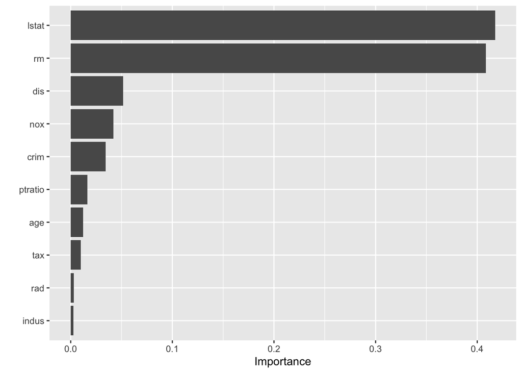

```r
library(vip)

final_tree %>%
  extract_fit_parsnip() %>%
  vip()
```

### 4.6 Summary

- I would choose **random forest** for predicting `medv`, because it has the lowest test rmse and highest test rsq.

## 5 ISL Lab 8.3 `Carseats` data set (30pts)

Follow the machine learning workflow to train classification tree, random forest, and boosting methods for classifying `Sales <= 8` versus `Sales > 8`. Evaluate out-of-sample performance on a test set.

### 5.1 Careseats dataset

```r
str(Carseats)
```

```
'data.frame':   400 obs. of  11 variables:
 $ Sales      : num  9.5 11.22 10.06 7.4 4.15 ...
 $ CompPrice  : num  138 111 113 117 141 124 115 136 132 132 ...
 $ Income     : num  73 48 35 100 64 113 105 81 110 113 ...
 $ Advertising: num  11 16 10 4 3 13 0 15 0 0 ...
 $ Population : num  276 260 269 466 340 501 45 425 108 131 ...
 $ Price      : num  120 83 80 97 128 72 108 120 124 124 ...
 $ ShelveLoc  : Factor w/ 3 levels "Bad","Good","Medium": 1 2 3 3 1 1 3 2 3 3 ...
 $ Age        : num  42 65 59 55 38 78 71 67 76 76 ...
 $ Education  : num  17 10 12 14 13 16 15 10 10 17 ...
 $ Urban      : Factor w/ 2 levels "No","Yes": 2 2 2 2 2 1 2 2 1 1 ...
 $ US         : Factor w/ 2 levels "No","Yes": 2 2 2 2 1 2 1 2 1 2 ...
```

```r
Carseats$Sales <- ifelse(Carseats$Sales <= 8, "0", "1")
Carseats$Sales <- factor(Carseats$Sales)
```

```r
Carseats <- na.omit(Carseats)
Carseats %>% tbl_summary()
```

| **Characteristic** | **N = 400**<sup>1</sup> |
| --- | --- |
| Sales |  |
| 0 | 236 (59%) |
| 1 | 164 (41%) |
| CompPrice | 125 (115, 135) |
| Income | 69 (43, 91) |
| Advertising | 5.0 (0.0, 12.0) |
| Population | 272 (139, 399) |
| Price | 117 (100, 131) |
| ShelveLoc |  |
| Bad | 96 (24%) |
| Good | 85 (21%) |
| Medium | 219 (55%) |
| Age | 55 (40, 66) |
| Education |  |
| 10 | 48 (12%) |
| 11 | 48 (12%) |
| 12 | 49 (12%) |
| 13 | 43 (11%) |
| 14 | 40 (10%) |
| 15 | 36 (9.0%) |
| 16 | 47 (12%) |
| 17 | 49 (12%) |
| 18 | 40 (10%) |
| Urban | 282 (71%) |
| US | 258 (65%) |

<sup>1</sup> n (%); Median (IQR)

- The goal is to predict `Sales <= 8` versus `Sales > 8`

### 5.2 Initial split into test and non-test sets

```r
# For reproducibility
set.seed(210)

data_split <- initial_split(
  Carseats,
  prop = 0.5,
  strata = Sales
  )
data_split
```

```
<Training/Testing/Total>
<200/200/400>
```

```r
Carseats_other <- training(data_split)
dim(Carseats_other)
```

```
[1] 200  11
```

```r
Carseats_test <- testing(data_split)
dim(Carseats_test)
```

```
[1] 200  11
```

### 5.3 Classification tree

#### 5.3.1 Recipe

```r
tree_recipe <-
  recipe(
    Sales ~ .,
    data = Carseats_other
  ) %>%
  step_naomit(all_predictors()) %>%
  # # create traditional dummy variables (not necessary for random forest in R)
  step_dummy(all_nominal_predictors()) %>%
  # zero-variance filter
  step_zv(all_numeric_predictors()) %>%
  # # center and scale numeric data (not necessary for random forest)
  step_normalize(all_numeric_predictors()) %>%
  # estimate the means and standard deviations
  prep(training = Carseats_other, retain = TRUE)
tree_recipe
```

#### 5.3.2 Model

```r
classtree_mod <- decision_tree(
  cost_complexity = tune(),
  tree_depth = tune(),
  min_n = 5,
  mode = "classification",
  engine = "rpart"
  )
```

#### 5.3.3 Workflow

```r
tree_wf <- workflow() %>%
  add_recipe(tree_recipe) %>%
  add_model(classtree_mod)
tree_wf
```

```
══ Workflow ════════════════════════════════════════════════════════════════════
Preprocessor: Recipe
Model: decision_tree()

── Preprocessor ────────────────────────────────────────────────────────────────
4 Recipe Steps

• step_naomit()
• step_dummy()
• step_zv()
• step_normalize()

── Model ───────────────────────────────────────────────────────────────────────
Decision Tree Model Specification (classification)

Main Arguments:
  cost_complexity = tune()
  tree_depth = tune()
  min_n = 5

Computational engine: rpart
```

#### 5.3.4 Tuning grid

```r
tree_grid <- grid_regular(cost_complexity(),
                          tree_depth(),
                          levels = c(100,5))
```

#### 5.3.5 Cross-validation (CV)

```r
set.seed(212)

folds <- vfold_cv(Carseats_other, v = 5)
folds
```

```
#  5-fold cross-validation
# A tibble: 5 × 2
  splits           id
  <list>           <chr>
1 <split [160/40]> Fold1
2 <split [160/40]> Fold2
3 <split [160/40]> Fold3
4 <split [160/40]> Fold4
5 <split [160/40]> Fold5
```

Fit cross-validation.

```r
tree_fit <- tree_wf %>%
  tune_grid(
    resamples = folds,
    grid = tree_grid,
    metrics = metric_set(accuracy, roc_auc)
    )
tree_fit
```

```
# Tuning results
# 5-fold cross-validation
# A tibble: 5 × 4
  splits           id    .metrics             .notes
  <list>           <chr> <list>               <list>
1 <split [160/40]> Fold1 <tibble [1,000 × 6]> <tibble [0 × 3]>
2 <split [160/40]> Fold2 <tibble [1,000 × 6]> <tibble [0 × 3]>
3 <split [160/40]> Fold3 <tibble [1,000 × 6]> <tibble [0 × 3]>
4 <split [160/40]> Fold4 <tibble [1,000 × 6]> <tibble [0 × 3]>
5 <split [160/40]> Fold5 <tibble [1,000 × 6]> <tibble [0 × 3]>
```

Visualize CV results:

```
# A tibble: 1,000 × 8
   cost_complexity tree_depth .metric  .estimator  mean     n std_err
             <dbl>      <int> <chr>    <chr>      <dbl> <int>   <dbl>
 1        1   e-10          1 accuracy binary     0.68      5  0.0382
 2        1   e-10          1 roc_auc  binary     0.635     5  0.0273
 3        1.23e-10          1 accuracy binary     0.68      5  0.0382
 4        1.23e-10          1 roc_auc  binary     0.635     5  0.0273
 5        1.52e-10          1 accuracy binary     0.68      5  0.0382
 6        1.52e-10          1 roc_auc  binary     0.635     5  0.0273
 7        1.87e-10          1 accuracy binary     0.68      5  0.0382
 8        1.87e-10          1 roc_auc  binary     0.635     5  0.0273
 9        2.31e-10          1 accuracy binary     0.68      5  0.0382
10        2.31e-10          1 roc_auc  binary     0.635     5  0.0273
   .config
   <chr>
 1 Preprocessor1_Model001
 2 Preprocessor1_Model001
 3 Preprocessor1_Model002
 4 Preprocessor1_Model002
 5 Preprocessor1_Model003
 6 Preprocessor1_Model003
 7 Preprocessor1_Model004
 8 Preprocessor1_Model004
 9 Preprocessor1_Model005
10 Preprocessor1_Model005
# ℹ 990 more rows
```

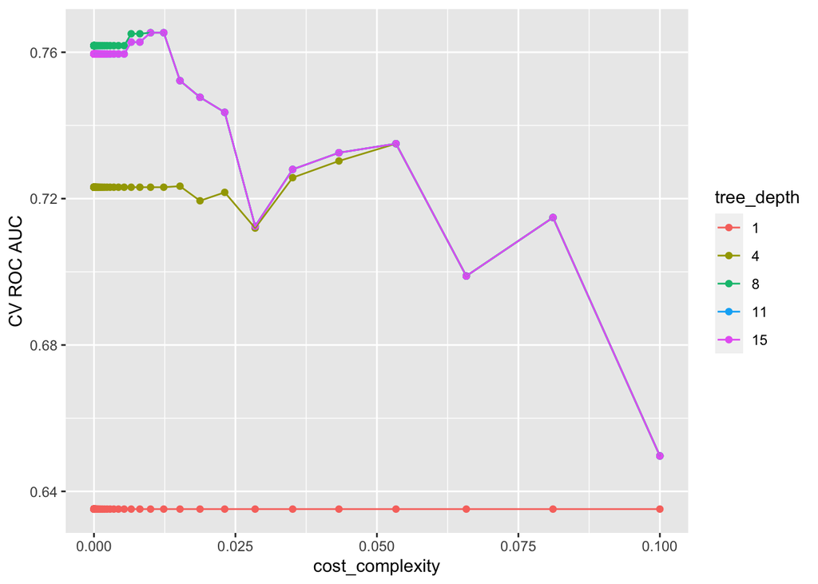

```r
tree_fit %>%
  collect_metrics() %>%
  print(width = Inf) %>%
  filter(.metric == "roc_auc") %>%
  mutate(tree_depth = as.factor(tree_depth)) %>%
  ggplot(mapping = aes(x = cost_complexity, y = mean, color = tree_depth)) +
  geom_point() +
  geom_line() +
  labs(x = "cost_complexity", y = "CV ROC AUC", color = "tree_depth")
```

#### 5.3.6 Finalize our model

Now we are done tuning. Finally, let’s fit this final model to the whole training data and use our test data to estimate the model performance we expect to see with new data.

```r
tree_fit %>%
  show_best("roc_auc")
```

```
# A tibble: 5 × 8
  cost_complexity tree_depth .metric .estimator  mean     n std_err .config
            <dbl>      <int> <chr>   <chr>      <dbl> <int>   <dbl> <chr>
1          0.01            8 roc_auc binary     0.765     5  0.0423 Preprocesso…
2          0.0123          8 roc_auc binary     0.765     5  0.0423 Preprocesso…
3          0.01           11 roc_auc binary     0.765     5  0.0423 Preprocesso…
4          0.0123         11 roc_auc binary     0.765     5  0.0423 Preprocesso…
5          0.01           15 roc_auc binary     0.765     5  0.0423 Preprocesso…
```

Let’s select the best model.

```r
best_tree <- tree_fit %>%
  select_best("roc_auc")
best_tree
```

```
# A tibble: 1 × 3
  cost_complexity tree_depth .config
            <dbl>      <int> <chr>
1            0.01          8 Preprocessor1_Model289
```

```r
# Final workflow
final_wf <- tree_wf %>%
  finalize_workflow(best_tree)
final_wf
```

```
══ Workflow ════════════════════════════════════════════════════════════════════
Preprocessor: Recipe
Model: decision_tree()

── Preprocessor ────────────────────────────────────────────────────────────────
4 Recipe Steps

• step_naomit()
• step_dummy()
• step_zv()
• step_normalize()

── Model ───────────────────────────────────────────────────────────────────────
Decision Tree Model Specification (classification)

Main Arguments:
  cost_complexity = 0.01
  tree_depth = 8
  min_n = 5

Computational engine: rpart
```

```r
# Fit the whole training set, then predict the test cases
final_fit <-
  final_wf %>%
  last_fit(data_split)
final_fit
```

```
# Resampling results
# Manual resampling
# A tibble: 1 × 6
  splits            id               .metrics .notes   .predictions .workflow
  <list>            <chr>            <list>   <list>   <list>       <list>
1 <split [200/200]> train/test split <tibble> <tibble> <tibble>     <workflow>
```

```r
# Test metrics
final_fit %>%
  collect_metrics()
```

```
# A tibble: 2 × 4
  .metric  .estimator .estimate .config
  <chr>    <chr>          <dbl> <chr>
1 accuracy binary         0.74  Preprocessor1_Model1
2 roc_auc  binary         0.756 Preprocessor1_Model1
```

#### 5.3.7 Visualize the final model

```r
library(rpart.plot)
final_tree <- extract_workflow(final_fit)
final_tree
```

```
══ Workflow [trained] ══════════════════════════════════════════════════════════
Preprocessor: Recipe
Model: decision_tree()

── Preprocessor ────────────────────────────────────────────────────────────────
4 Recipe Steps

• step_naomit()
• step_dummy()
• step_zv()
• step_normalize()

── Model ───────────────────────────────────────────────────────────────────────
n= 200

node), split, n, loss, yval, (yprob)
      * denotes terminal node

  1) root 200 82 0 (0.59000000 0.41000000)
    2) ShelveLoc_Good< 0.6234373 153 45 0 (0.70588235 0.29411765)
      4) Price>=-0.6540898 115 22 0 (0.80869565 0.19130435)
        8) Advertising< 2.496434 112 19 0 (0.83035714 0.16964286)
         16) Age>=-0.2763153 68  6 0 (0.91176471 0.08823529)
           32) Price>=-0.405544 58  2 0 (0.96551724 0.03448276)
             64) CompPrice< 1.471172 52  0 0 (1.00000000 0.00000000) *
             65) CompPrice>=1.471172 6  2 0 (0.66666667 0.33333333)
              130) Income< 0.2876565 4  0 0 (1.00000000 0.00000000) *
              131) Income>=0.2876565 2  0 1 (0.00000000 1.00000000) *
           33) Price< -0.405544 10  4 0 (0.60000000 0.40000000)
             66) Advertising>=0.5594814 5  0 0 (1.00000000 0.00000000) *
             67) Advertising< 0.5594814 5  1 1 (0.20000000 0.80000000) *
         17) Age< -0.2763153 44 13 0 (0.70454545 0.29545455)
           34) Price>=0.9614582 13  0 0 (1.00000000 0.00000000) *
           35) Price< 0.9614582 31 13 0 (0.58064516 0.41935484)
             70) Advertising< -0.4089951 15  3 0 (0.80000000 0.20000000)
              140) CompPrice< 0.3132899 8  0 0 (1.00000000 0.00000000) *
              141) CompPrice>=0.3132899 7  3 0 (0.57142857 0.42857143)
                282) Advertising>=-0.8559842 3  0 0 (1.00000000 0.00000000) *
                283) Advertising< -0.8559842 4  1 1 (0.25000000 0.75000000) *
             71) Advertising>=-0.4089951 16  6 1 (0.37500000 0.62500000)
```

[output cut: 11 more lines]

```
              162) CompPrice>=-0.4476042 4  0 0 (1.00000000 0.00000000) *
              163) CompPrice< -0.4476042 5  1 1 (0.20000000 0.80000000) *
           41) Price< -2.269638 2  0 1 (0.00000000 1.00000000) *
         21) Advertising>=0.410485 10  2 1 (0.20000000 0.80000000)
           42) Age>=1.089738 3  1 0 (0.66666667 0.33333333) *
           43) Age< 1.089738 7  0 1 (0.00000000 1.00000000) *
       11) Age< -0.7420152 9  0 1 (0.00000000 1.00000000) *
    3) ShelveLoc_Good>=0.6234373 47 10 1 (0.21276596 0.78723404)
      6) Price>=1.085731 6  1 0 (0.83333333 0.16666667) *
      7) Price< 1.085731 41  5 1 (0.12195122 0.87804878)
       14) Income< -1.18656 11  4 1 (0.36363636 0.63636364)
         28) Price>=-0.281271 5  1 0 (0.80000000 0.20000000) *

...
and 2 more lines.
```

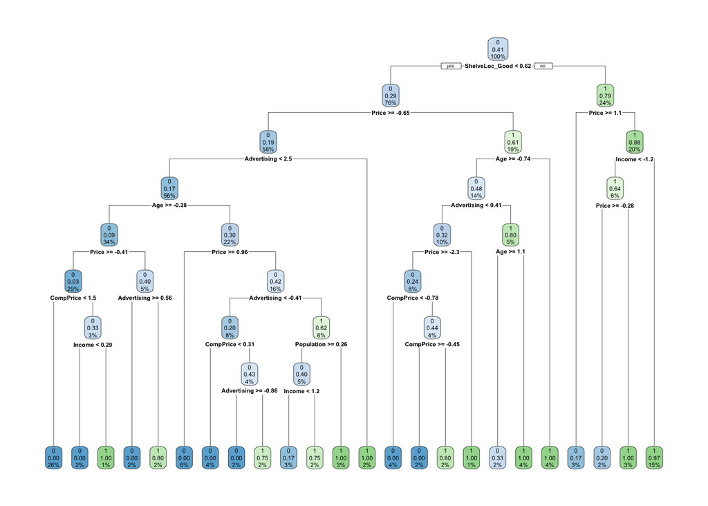

```r
final_tree %>%
  extract_fit_engine() %>%
  rpart.plot(roundint = FALSE)
```

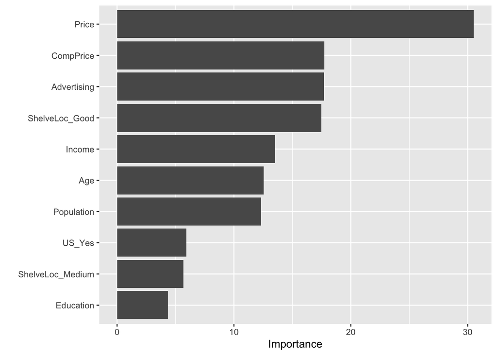

```r
library(vip)

final_tree %>%
  extract_fit_parsnip() %>%
  vip()
```

### 5.4 Random forest

#### 5.4.1 Recipe

```r
rf_recipe <-
  recipe(
    Sales ~ .,
    data = Carseats_other
  ) %>%
  step_zv(all_numeric_predictors()) %>%
  prep(training = Carseats_other, retain = TRUE)
rf_recipe
```

#### 5.4.2 Model

```r
rf_mod <-
  rand_forest(
    mode = "classification",
    mtry = tune(),
    trees = tune()
  ) %>%
  set_engine("ranger")
rf_mod
```

```
Random Forest Model Specification (classification)

Main Arguments:
  mtry = tune()
  trees = tune()

Computational engine: ranger
```

#### 5.4.3 Workflow

```r
rf_wf <- workflow() %>%
  add_recipe(rf_recipe) %>%
  add_model(rf_mod)
rf_wf
```

```
══ Workflow ════════════════════════════════════════════════════════════════════
Preprocessor: Recipe
Model: rand_forest()

── Preprocessor ────────────────────────────────────────────────────────────────
1 Recipe Step

• step_zv()

── Model ───────────────────────────────────────────────────────────────────────
Random Forest Model Specification (classification)

Main Arguments:
  mtry = tune()
  trees = tune()

Computational engine: ranger
```

#### 5.4.4 Tuning grid

```r
param_grid <- grid_regular(
  mtry(range = c(1L, 5L)),
  trees(range = c(100L, 300L)),
  levels = c(3, 5)
  )
param_grid
```

```
# A tibble: 15 × 2
    mtry trees
   <int> <int>
 1     1   100
 2     3   100
 3     5   100
 4     1   150
 5     3   150
 6     5   150
 7     1   200
 8     3   200
 9     5   200
10     1   250
11     3   250
12     5   250
13     1   300
14     3   300
15     5   300
```

#### 5.4.5 Cross-validation (CV)

```r
set.seed(212)

folds <- vfold_cv(Carseats_other, v = 5)
folds
```

```
#  5-fold cross-validation
# A tibble: 5 × 2
  splits           id
  <list>           <chr>
1 <split [160/40]> Fold1
2 <split [160/40]> Fold2
3 <split [160/40]> Fold3
4 <split [160/40]> Fold4
5 <split [160/40]> Fold5
```

Fit cross-validation.

```r
rf_fit <- rf_wf %>%
  tune_grid(
    resamples = folds,
    grid = param_grid,
    metrics = metric_set(accuracy, roc_auc)
    )
rf_fit
```

```
# Tuning results
# 5-fold cross-validation
# A tibble: 5 × 4
  splits           id    .metrics          .notes
  <list>           <chr> <list>            <list>
1 <split [160/40]> Fold1 <tibble [30 × 6]> <tibble [0 × 3]>
2 <split [160/40]> Fold2 <tibble [30 × 6]> <tibble [0 × 3]>
3 <split [160/40]> Fold3 <tibble [30 × 6]> <tibble [0 × 3]>
4 <split [160/40]> Fold4 <tibble [30 × 6]> <tibble [0 × 3]>
5 <split [160/40]> Fold5 <tibble [30 × 6]> <tibble [0 × 3]>
```

Visualize CV results:

```
# A tibble: 30 × 8
    mtry trees .metric  .estimator  mean     n std_err .config
   <int> <int> <chr>    <chr>      <dbl> <int>   <dbl> <chr>
 1     1   100 accuracy binary     0.72      5  0.02   Preprocessor1_Model01
 2     1   100 roc_auc  binary     0.812     5  0.0563 Preprocessor1_Model01
 3     3   100 accuracy binary     0.755     5  0.0289 Preprocessor1_Model02
 4     3   100 roc_auc  binary     0.818     5  0.0534 Preprocessor1_Model02
 5     5   100 accuracy binary     0.74      5  0.0170 Preprocessor1_Model03
 6     5   100 roc_auc  binary     0.826     5  0.0440 Preprocessor1_Model03
 7     1   150 accuracy binary     0.745     5  0.03   Preprocessor1_Model04
 8     1   150 roc_auc  binary     0.800     5  0.0487 Preprocessor1_Model04
 9     3   150 accuracy binary     0.76      5  0.0341 Preprocessor1_Model05
10     3   150 roc_auc  binary     0.823     5  0.0473 Preprocessor1_Model05
# ℹ 20 more rows
```

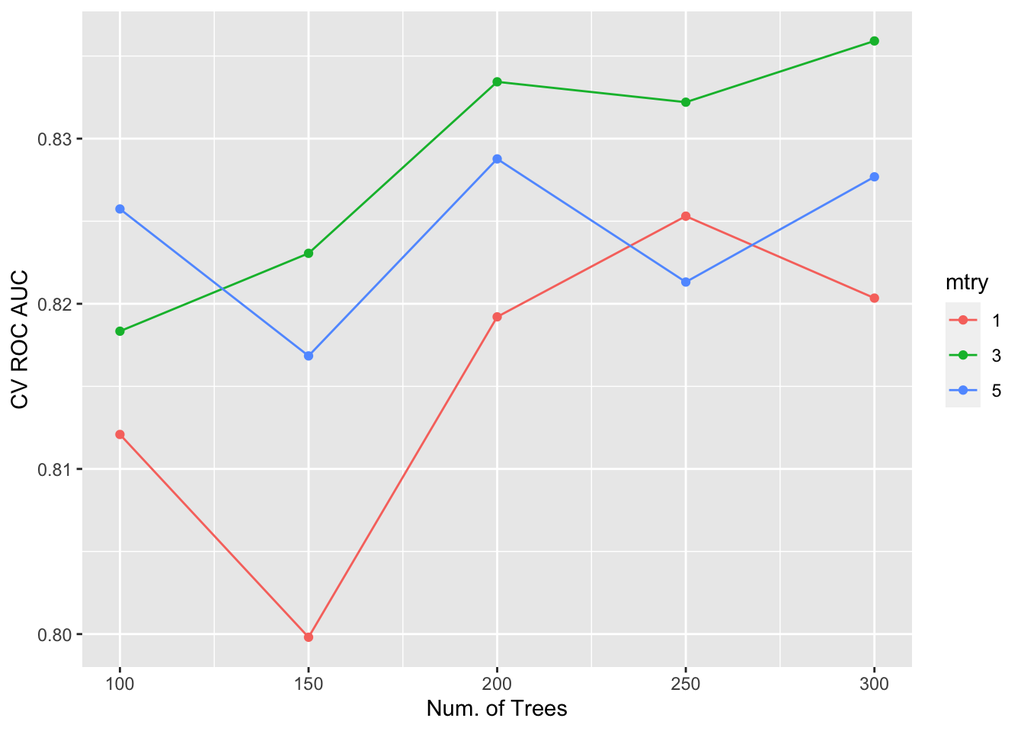

```r
rf_fit %>%
  collect_metrics() %>%
  print(width = Inf) %>%
  filter(.metric == "roc_auc") %>%
  mutate(mtry = as.factor(mtry)) %>%
  ggplot(mapping = aes(x = trees, y = mean, color = mtry)) +
  geom_point() +
  geom_line() +
  labs(x = "Num. of Trees", y = "CV ROC AUC")
```

Show the top 5 models.

```r
rf_fit %>%
  show_best("roc_auc")
```

```
# A tibble: 5 × 8
   mtry trees .metric .estimator  mean     n std_err .config
  <int> <int> <chr>   <chr>      <dbl> <int>   <dbl> <chr>
1     3   300 roc_auc binary     0.836     5  0.0481 Preprocessor1_Model14
2     3   200 roc_auc binary     0.833     5  0.0450 Preprocessor1_Model08
3     3   250 roc_auc binary     0.832     5  0.0465 Preprocessor1_Model11
4     5   200 roc_auc binary     0.829     5  0.0358 Preprocessor1_Model09
5     5   300 roc_auc binary     0.828     5  0.0413 Preprocessor1_Model15
```

Let’s select the best model.

```r
best_rf <- rf_fit %>%
  select_best("roc_auc")
best_rf
```

```
# A tibble: 1 × 3
   mtry trees .config
  <int> <int> <chr>
1     3   300 Preprocessor1_Model14
```

#### 5.4.6 Finalize our model

Now we are done tuning. Finally, let’s fit this final model to the whole training data and use our test data to estimate the model performance we expect to see with new data.

```r
# Final workflow
final_wf <- rf_wf %>%
  finalize_workflow(best_rf)
final_wf
```

```
══ Workflow ════════════════════════════════════════════════════════════════════
Preprocessor: Recipe
Model: rand_forest()

── Preprocessor ────────────────────────────────────────────────────────────────
1 Recipe Step

• step_zv()

── Model ───────────────────────────────────────────────────────────────────────
Random Forest Model Specification (classification)

Main Arguments:
  mtry = 3
  trees = 300

Computational engine: ranger
```

```r
# Fit the whole training set, then predict the test cases
final_fit <-
  final_wf %>%
  last_fit(data_split)
final_fit
```

```
# Resampling results
# Manual resampling
# A tibble: 1 × 6
  splits            id               .metrics .notes   .predictions .workflow
  <list>            <chr>            <list>   <list>   <list>       <list>
1 <split [200/200]> train/test split <tibble> <tibble> <tibble>     <workflow>
```

```r
# Test metrics
final_fit %>%
  collect_metrics()
```

```
# A tibble: 2 × 4
  .metric  .estimator .estimate .config
  <chr>    <chr>          <dbl> <chr>
1 accuracy binary         0.785 Preprocessor1_Model1
2 roc_auc  binary         0.861 Preprocessor1_Model1
```

### 5.5 Boosting

#### 5.5.1 Recipe

```r
gb_recipe <-
  recipe(
    Sales ~ .,
    data = Carseats_other
  ) %>%
  step_dummy(all_nominal_predictors()) %>%
  step_zv(all_numeric_predictors()) %>%
  prep(training = Carseats_other, retain = TRUE)
gb_recipe
```

#### 5.5.2 Model

```r
gb_mod <-
  boost_tree(
    mode = "classification",
    trees = 1000,
    tree_depth = tune(),
    learn_rate = tune()
  ) %>%
  set_engine("xgboost")
gb_mod
```

```
Boosted Tree Model Specification (classification)

Main Arguments:
  trees = 1000
  tree_depth = tune()
  learn_rate = tune()

Computational engine: xgboost
```

#### 5.5.3 Workflow

Here we bundle the recipe and model.

```r
gb_wf <- workflow() %>%
  add_recipe(gb_recipe) %>%
  add_model(gb_mod)
gb_wf
```

```
══ Workflow ════════════════════════════════════════════════════════════════════
Preprocessor: Recipe
Model: boost_tree()

── Preprocessor ────────────────────────────────────────────────────────────────
2 Recipe Steps

• step_dummy()
• step_zv()

── Model ───────────────────────────────────────────────────────────────────────
Boosted Tree Model Specification (classification)

Main Arguments:
  trees = 1000
  tree_depth = tune()
  learn_rate = tune()

Computational engine: xgboost
```

#### 5.5.4 Tuning grid

```r
param_grid <- grid_regular(
  tree_depth(range = c(1L, 3L)),
  learn_rate(range = c(-5, 2), trans = log10_trans()),
  levels = c(3, 10)
  )
param_grid
```

```
# A tibble: 30 × 2
   tree_depth learn_rate
        <int>      <dbl>
 1          1  0.00001
 2          2  0.00001
 3          3  0.00001
 4          1  0.0000599
 5          2  0.0000599
 6          3  0.0000599
 7          1  0.000359
 8          2  0.000359
 9          3  0.000359
10          1  0.00215
# ℹ 20 more rows
```

#### 5.5.5 Cross-validation (CV)

Set cross-validation partitions.

```r
set.seed(212)

folds <- vfold_cv(Carseats_other, v = 5)
folds
```

```
#  5-fold cross-validation
# A tibble: 5 × 2
  splits           id
  <list>           <chr>
1 <split [160/40]> Fold1
2 <split [160/40]> Fold2
3 <split [160/40]> Fold3
4 <split [160/40]> Fold4
5 <split [160/40]> Fold5
```

Fit cross-validation.

```r
gb_fit <- gb_wf %>%
  tune_grid(
    resamples = folds,
    grid = param_grid,
    metrics = metric_set(accuracy, roc_auc)
    )
gb_fit
```

```
# Tuning results
# 5-fold cross-validation
# A tibble: 5 × 4
  splits           id    .metrics          .notes
  <list>           <chr> <list>            <list>
1 <split [160/40]> Fold1 <tibble [60 × 6]> <tibble [0 × 3]>
2 <split [160/40]> Fold2 <tibble [60 × 6]> <tibble [0 × 3]>
3 <split [160/40]> Fold3 <tibble [60 × 6]> <tibble [0 × 3]>
4 <split [160/40]> Fold4 <tibble [60 × 6]> <tibble [0 × 3]>
5 <split [160/40]> Fold5 <tibble [60 × 6]> <tibble [0 × 3]>
```

Visualize CV results:

```
# A tibble: 60 × 8
   tree_depth learn_rate .metric  .estimator  mean     n std_err
        <int>      <dbl> <chr>    <chr>      <dbl> <int>   <dbl>
 1          1  0.00001   accuracy binary     0.68      5  0.0382
 2          1  0.00001   roc_auc  binary     0.635     5  0.0273
 3          2  0.00001   accuracy binary     0.755     5  0.0242
 4          2  0.00001   roc_auc  binary     0.765     5  0.0207
 5          3  0.00001   accuracy binary     0.685     5  0.0218
 6          3  0.00001   roc_auc  binary     0.732     5  0.0418
 7          1  0.0000599 accuracy binary     0.68      5  0.0382
 8          1  0.0000599 roc_auc  binary     0.635     5  0.0273
 9          2  0.0000599 accuracy binary     0.76      5  0.0232
10          2  0.0000599 roc_auc  binary     0.782     5  0.0316
   .config
   <chr>
 1 Preprocessor1_Model01
 2 Preprocessor1_Model01
 3 Preprocessor1_Model02
 4 Preprocessor1_Model02
 5 Preprocessor1_Model03
 6 Preprocessor1_Model03
 7 Preprocessor1_Model04
 8 Preprocessor1_Model04
 9 Preprocessor1_Model05
10 Preprocessor1_Model05
# ℹ 50 more rows
```

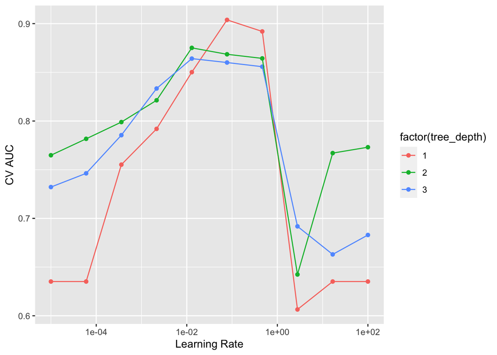

```r
gb_fit %>%
  collect_metrics() %>%
  print(width = Inf) %>%
  filter(.metric == "roc_auc") %>%
  mutate(tree_depth = as.factor(tree_depth)) %>%
  ggplot(mapping = aes(x = learn_rate, y = mean, color = factor(tree_depth))) +
  geom_point() +
  geom_line() +
  labs(x = "Learning Rate", y = "CV AUC") +
  scale_x_log10()
```

Show the top 5 models.

```r
gb_fit %>%
  show_best("roc_auc")
```

```
# A tibble: 5 × 8
  tree_depth learn_rate .metric .estimator  mean     n std_err .config
       <int>      <dbl> <chr>   <chr>      <dbl> <int>   <dbl> <chr>
1          1     0.0774 roc_auc binary     0.904     5  0.0253 Preprocessor1_Mo…
2          1     0.464  roc_auc binary     0.892     5  0.0289 Preprocessor1_Mo…
3          2     0.0129 roc_auc binary     0.875     5  0.0365 Preprocessor1_Mo…
4          2     0.0774 roc_auc binary     0.869     5  0.0406 Preprocessor1_Mo…
5          2     0.464  roc_auc binary     0.864     5  0.0383 Preprocessor1_Mo…
```

Let’s select the best model.

```r
best_gb <- gb_fit %>%
  select_best("roc_auc")
best_gb
```

```
# A tibble: 1 × 3
  tree_depth learn_rate .config
       <int>      <dbl> <chr>
1          1     0.0774 Preprocessor1_Model16
```

#### 5.5.6 Finalize our model

Now we are done tuning. Finally, let’s fit this final model to the whole training data and use our test data to estimate the model performance we expect to see with new data.

```r
# Final workflow
final_wf <- gb_wf %>%
  finalize_workflow(best_gb)
final_wf
```

```
══ Workflow ════════════════════════════════════════════════════════════════════
Preprocessor: Recipe
Model: boost_tree()

── Preprocessor ────────────────────────────────────────────────────────────────
2 Recipe Steps

• step_dummy()
• step_zv()

── Model ───────────────────────────────────────────────────────────────────────
Boosted Tree Model Specification (classification)

Main Arguments:
  trees = 1000
  tree_depth = 1
  learn_rate = 0.0774263682681127

Computational engine: xgboost
```

```r
# Fit the whole training set, then predict the test cases
final_fit <-
  final_wf %>%
  last_fit(data_split)
final_fit
```

```
# Resampling results
# Manual resampling
# A tibble: 1 × 6
  splits            id               .metrics .notes   .predictions .workflow
  <list>            <chr>            <list>   <list>   <list>       <list>
1 <split [200/200]> train/test split <tibble> <tibble> <tibble>     <workflow>
```

```r
# Test metrics
final_fit %>%
  collect_metrics()
```

```
# A tibble: 2 × 4
  .metric  .estimator .estimate .config
  <chr>    <chr>          <dbl> <chr>
1 accuracy binary         0.84  Preprocessor1_Model1
2 roc_auc  binary         0.920 Preprocessor1_Model1
```

#### 5.5.7 Summary

- I would choose **boosting** for classifying `Sales <= 8` versus `Sales > 8`, because it has the highest test roc_auc and accuracy.